# Assignment Week 2_Reference Solution

## Week 2 Assignment Solution

### 1. Dataset Generation (10 points)

Generate a training dataset based on the equation (y = 10x + 15), and generate a separate dataset for evaluation.

### 2. Model Evaluation Using MAE (10 points)

Use **Mean Absolute Error (MAE)** to evaluate the performance of the model developed in Question 1.

### 3. Ridge Regression (40 points)

In Section 3.4, **Ridge Regression**, try the following values of `alpha`: **0.001, 0.01, and 0.1**.

Evaluate the performance of the three Ridge Regression models and compare their results. Identify which `alpha` value provides the best model performance.

### 4. Airbnb Price Prediction (40 points)

In Section 3.6, **Airbnb Price Prediction**, add **`cancellation_policy`** as an additional predictor to the linear regression model.

Evaluate the performance of the new model and compare it with the original model.

### Question 1

```python
import numpy.random as rnd # This is a library for random number generation
X = 2 * rnd.rand(100, 1)
y = 15 + 10 * X + rnd.randn(100, 1)
```

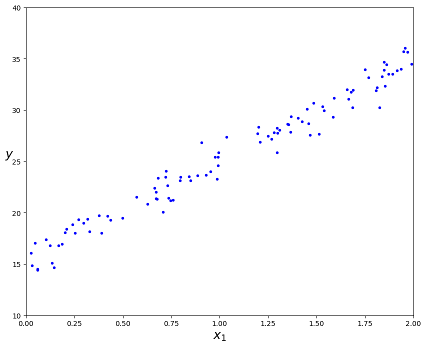

```python
import matplotlib.pyplot as plt
from matplotlib.pylab import rcParams
rcParams['figure.figsize'] = 10, 8
## "b." blue dots
plt.plot(X, y, "b.")
#plt.plot(X, y, color="blue", marker=".")
# $...$ tells Matplotlib to interpret the text as mathematical notation using its mathtext system
plt.xlabel("$x_1$", fontsize=18)
plt.ylabel("$y$", rotation=0, fontsize=18)
plt.axis([0, 2, 10, 40])
plt.savefig("generated_data_plot.png")
plt.show()
```

```python
from sklearn.linear_model import LinearRegression
lin_reg = LinearRegression() # Define your model
lin_reg.fit(X, y)  # Fit your model using the data
#This step shows the intercept and coefficients of your fit result
print('Slope is %f, Intercept is %f'%(lin_reg.coef_[0][0], lin_reg.intercept_[0]))
print('Linear Function is y=%f * x + %f'%(lin_reg.coef_[0][0], lin_reg.intercept_[0]))
```

```
Slope is 9.725096, Intercept is 15.315972
Linear Function is y=9.725096 * x + 15.315972
```

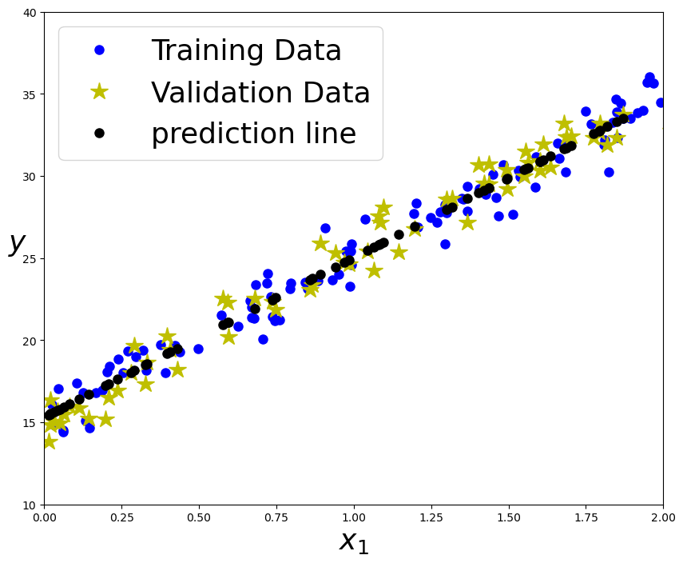

```python
X_new=3 * rnd.rand(100, 1) # We generate a set of new data points of X
Y_new = 15 + 10 * X_new + rnd.randn(100, 1) # We generate a set of new data points of Y

# We use the regression model to predict the Y value of the new data points
Y_new_predict=lin_reg.predict(X_new)

plt.plot(X, y, "b.",markersize=16)
plt.plot(X_new,Y_new,"*",color='y',markersize=16)
plt.plot(X_new,Y_new_predict,"k.",markersize=16)
plt.xlabel("$x_1$", fontsize=26)
plt.ylabel("$y$", rotation=0, fontsize=26)
plt.axis([0, 2, 10, 40])
plt.legend(['Training Data','Validation Data','prediction line'],fontsize=26)
plt.show()
```

### Question 2

```python
from sklearn.metrics import r2_score
from sklearn.metrics import mean_absolute_error
evaluation_result=r2_score(Y_new, Y_new_predict)
print('R2=%f' %evaluation_result)
evaluation_result=mean_absolute_error(Y_new, Y_new_predict)
print('Mean absolute error=%f' %evaluation_result)
```

```
R2=0.986954
Mean absolute error=0.799716
```

### Question 3

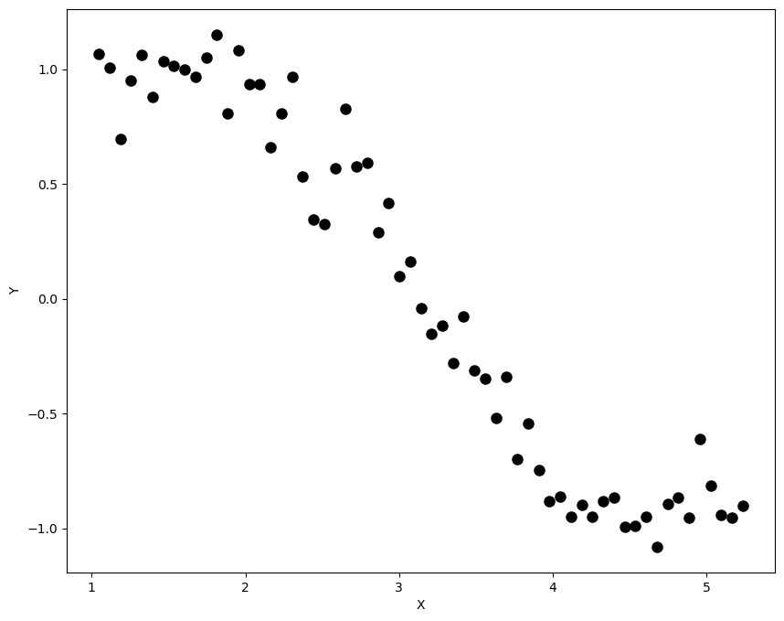

```
          x         y       x^2       x^3       x^4       x^5       x^6  \
0  1.047198  1.065763  1.096623  1.148381  1.202581  1.259340  1.318778
1  1.117011  1.006086  1.247713  1.393709  1.556788  1.738948  1.942424
2  1.186824  0.695374  1.408551  1.671702  1.984016  2.354677  2.794587
3  1.256637  0.949799  1.579137  1.984402  2.493673  3.133642  3.937850
4  1.326450  1.063496  1.759470  2.333850  3.095735  4.106339  5.446854

        x^7       x^8        x^9       x^10       x^11       x^12       x^13  \
0  1.381021  1.446202   1.514459   1.585938   1.660790   1.739176   1.821260
1  2.169709  2.423588   2.707173   3.023942   3.377775   3.773011   4.214494
2  3.316683  3.936319   4.671717   5.544505   6.580351   7.809718   9.268760
3  4.948448  6.218404   7.814277   9.819710  12.339811  15.506664  19.486248
4  7.224981  9.583578  12.712139  16.862020  22.366630  29.668222  39.353420

        x^14       x^15
0   1.907219   1.997235
1   4.707635   5.258479
2  11.000386  13.055521
3  24.487142  30.771450
4  52.200353  69.241170
```

```python
#Import the libraries
import numpy as np
import pandas as pd
import random
import matplotlib.pyplot as plt

#Define input array with angles from 60° to 300°, converted from degrees to radians.
x = np.array([i*np.pi/180 for i in range(60,304,4)])
np.random.seed(10)  #Sets the random seed for NumPy's random-number generator.
# np.random.normal(mean, standard_deviation, number_of_values)
y = np.sin(x) + np.random.normal(0,0.15,len(x))
#column_stack() combines the two arrays side by side as columns.
data = pd.DataFrame(np.column_stack([x,y]),columns=['x','y'])

plt.plot(data['x'],data['y'],"k.",markersize=16)
plt.xlabel('X')
plt.ylabel('Y')
plt.show()

#Create polynomial variables (x^2, x^3, ..., x^{15}) in your DataFrame.
for i in range(2,16):  #power of 1 is already there
    colname = 'x^%d'%i      #new var will be x_powerb
    data[colname] = data['x']**i
print(data.head())
```

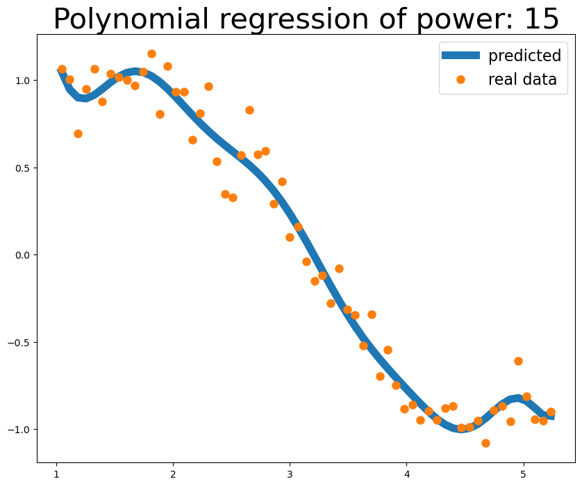

```python
from sklearn.linear_model import LinearRegression
power=15
predictors=['x']
predictors.extend(['x^%d'%i for i in range(2,power+1)])
linreg = LinearRegression()
linreg.fit(data[predictors],data['y'])
y_pred = linreg.predict(data[predictors])

plt.plot(data['x'],y_pred,linewidth=8)
plt.plot(data['x'],data['y'],'.',markersize=16)
plt.title('Polynomial regression of power: %d'%power,fontsize=30)
plt.legend(['predicted','real data'],fontsize=16)
plt.show()
```

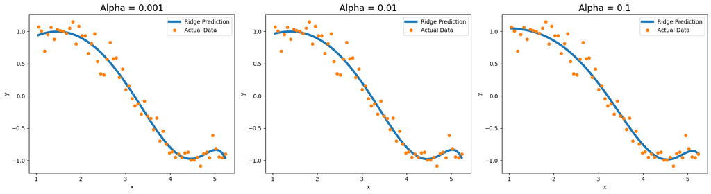

```python
import matplotlib.pyplot as plt
from sklearn.linear_model import Ridge
from sklearn.preprocessing import StandardScaler
from sklearn.pipeline import make_pipeline

alphas = [0.001, 0.01, 0.1]

# Set up a figure with 3 subplots (1 row, 3 columns)
fig, axes = plt.subplots(1, 3, figsize=(18, 5))

for ax, alpha in zip(axes, alphas):
    # Create pipeline with StandardScaler to fix the LinAlgWarning
    model = make_pipeline(StandardScaler(), Ridge(alpha=alpha))

    # Fit the model
    model.fit(data[predictors], data['y'])

    # Predict
    y_pred = model.predict(data[predictors])

    # Plot
    ax.plot(data['x'], y_pred, linewidth=4, label='Ridge Prediction')
    ax.plot(data['x'], data['y'], '.', markersize=10, label='Actual Data')
    ax.set_title(f'Alpha = {alpha}', fontsize=16)
    ax.set_xlabel('x')
    ax.set_ylabel('y')
    ax.legend()

plt.tight_layout()
plt.show()
```

```python
import pandas as pd
import numpy as np
from sklearn.linear_model import Ridge
from sklearn.preprocessing import StandardScaler
from sklearn.pipeline import make_pipeline
from sklearn.metrics import r2_score, mean_absolute_error, mean_squared_error

# Define the alpha values
alphas = [0.001, 0.01, 0.1]

# Create an empty list to store the results
results_list = []

# Loop through each alpha
for alpha in alphas:
    # Use a pipeline to standardize the data first, then apply Ridge
    # This fixes the Ill-conditioned matrix warning
    ridge = make_pipeline(StandardScaler(), Ridge(alpha=alpha))

    # Fit the model
    ridge.fit(data[predictors], data['y'])

    # Predict
    y_pred = ridge.predict(data[predictors])

    # Calculate all three metrics
    r2 = r2_score(data['y'], y_pred)
    mae = mean_absolute_error(data['y'], y_pred)
    rmse = np.sqrt(mean_squared_error(data['y'], y_pred)) # Correct RMSE formula

    # Append the results as a dictionary to the list
    results_list.append({
        'Alpha': alpha,
        'R² Score': r2,
        'MAE': mae,
        'RMSE': rmse
    })

# Convert the list of dictionaries into a pandas DataFrame
results_df = pd.DataFrame(results_list)

# Display the comparison table
print("Comparison Table for Ridge Regression:")
display(results_df) # Use display() if in Jupyter Notebook, otherwise use print()
```

```
Comparison Table for Ridge Regression:
```

|  | Alpha | R² Score | MAE | RMSE |
| --- | --- | --- | --- | --- |
| 0 | 0.001 | 0.974382 | 0.096326 | 0.126021 |
| 1 | 0.010 | 0.974255 | 0.096868 | 0.126331 |
| 2 | 0.100 | 0.971888 | 0.102846 | 0.132011 |

When comparing the three models, we look for the highest R² Score and the lowest error metrics (MAE and RMSE):

alpha = 0.001: R² = 0.974382 (Highest), RMSE = 0.126021 (Lowest), MAE = 0.096326 (Lowest) 👍 Winner

alpha = 0.010: R² = 0.974255, RMSE = 0.126331, MAE = 0.096868 (Performance is very close to 0.001, but slightly worse)

alpha = 0.100: R² = 0.971888 (Lowest), RMSE = 0.132011 (Highest), MAE = 0.102846 (Highest) (Worst performance)

### Question 4

```python
import pandas as pd
from sklearn.preprocessing import OneHotEncoder

ResearchData = pd.read_csv('Airbnb.csv')

feature_original = ['property_type', 'accommodates', 'bathrooms', 'bedrooms', 'beds']
target = 'log_price'

x_original = ResearchData[feature_original].copy()

enc_original = OneHotEncoder(drop='first')
enc_original.fit(x_original[['property_type']])
print(enc_original.categories_)

enc_original_df = pd.DataFrame(enc_original.transform(x_original[['property_type']]).toarray(),
                               columns=['House', 'Loft', 'Town House'])
x_original = x_original.join(enc_original_df)
x_original = x_original.drop('property_type', axis=1)
x_original.head()
```

```
[array(['Apartment', 'House', 'Loft', 'Townhouse'], dtype=object)]
```

|  | accommodates | bathrooms | bedrooms | beds | House | Loft | Town House |
| --- | --- | --- | --- | --- | --- | --- | --- |
| 0 | 3 | 1.0 | 1 | 1 | 0.0 | 0.0 | 0.0 |
| 1 | 7 | 1.0 | 3 | 3 | 0.0 | 0.0 | 0.0 |
| 2 | 5 | 1.0 | 1 | 3 | 0.0 | 0.0 | 0.0 |
| 3 | 4 | 1.0 | 2 | 2 | 1.0 | 0.0 | 0.0 |
| 4 | 2 | 1.0 | 0 | 1 | 0.0 | 0.0 | 0.0 |

```python
from sklearn.linear_model import LinearRegression
from sklearn.model_selection import train_test_split
from sklearn.metrics import mean_absolute_error, r2_score

y_airbnb = ResearchData[target]

x_train, x_test, y_train, y_test = train_test_split(x_original, y_airbnb, test_size=0.30, random_state=0)

lin_reg_original = LinearRegression()
lin_reg_original.fit(x_train, y_train)

y_pred_original = lin_reg_original.predict(x_test)

MAE_original = mean_absolute_error(y_test, y_pred_original)
R2_original = r2_score(y_test, y_pred_original)

print('Predictors:', x_original.columns.tolist())
print('Coefficients:', lin_reg_original.coef_)
print('Intercept:', lin_reg_original.intercept_)
print('Original model MAE = %f' % MAE_original)
print('Original model R2 = %f' % R2_original)
```

```
Predictors: ['accommodates', 'bathrooms', 'bedrooms', 'beds', 'House', 'Loft', 'Town House']
Coefficients: [ 0.17000603  0.13795161  0.12490194 -0.05628411 -0.19173624  0.12103869
 -0.17429126]
Intercept: 4.057529625004383
Original model MAE = 0.438920
Original model R2 = 0.359504
```

```python
feature_new = ['property_type', 'cancellation_policy', 'accommodates', 'bathrooms', 'bedrooms', 'beds']
x_new = ResearchData[feature_new].copy()

enc_new = OneHotEncoder(drop='first')
enc_new.fit(x_new[['property_type', 'cancellation_policy']])
print(enc_new.categories_)

enc_new_df = pd.DataFrame(enc_new.transform(x_new[['property_type', 'cancellation_policy']]).toarray(),
                          columns=enc_new.get_feature_names_out(['property_type', 'cancellation_policy']))
x_new = x_new.join(enc_new_df)
x_new = x_new.drop(['property_type', 'cancellation_policy'], axis=1)
x_new.head()
```

```
[array(['Apartment', 'House', 'Loft', 'Townhouse'], dtype=object), array(['flexible', 'moderate', 'strict', 'super_strict_30',
       'super_strict_60'], dtype=object)]
```

|  | accommodates | bathrooms | bedrooms | beds | property_type_House | property_type_Loft | property_type_Townhouse | cancellation_policy_moderate | cancellation_policy_strict | cancellation_policy_super_strict_30 | cancellation_policy_super_strict_60 |
| --- | --- | --- | --- | --- | --- | --- | --- | --- | --- | --- | --- |
| 0 | 3 | 1.0 | 1 | 1 | 0.0 | 0.0 | 0.0 | 0.0 | 1.0 | 0.0 | 0.0 |
| 1 | 7 | 1.0 | 3 | 3 | 0.0 | 0.0 | 0.0 | 0.0 | 1.0 | 0.0 | 0.0 |
| 2 | 5 | 1.0 | 1 | 3 | 0.0 | 0.0 | 0.0 | 1.0 | 0.0 | 0.0 | 0.0 |
| 3 | 4 | 1.0 | 2 | 2 | 1.0 | 0.0 | 0.0 | 0.0 | 0.0 | 0.0 | 0.0 |
| 4 | 2 | 1.0 | 0 | 1 | 0.0 | 0.0 | 0.0 | 1.0 | 0.0 | 0.0 | 0.0 |

```python
x_train_new, x_test_new, y_train_new, y_test_new = train_test_split(x_new, y_airbnb, test_size=0.30, random_state=0)

lin_reg_new = LinearRegression()
lin_reg_new.fit(x_train_new, y_train_new)

y_pred_new = lin_reg_new.predict(x_test_new)

MAE_new = mean_absolute_error(y_test_new, y_pred_new)
R2_new = r2_score(y_test_new, y_pred_new)

print('Predictors:', x_new.columns.tolist())
print('Coefficients:', lin_reg_new.coef_)
print('Intercept:', lin_reg_new.intercept_)
print('New model MAE = %f' % MAE_new)
print('New model R2 = %f' % R2_new)
```

```
Predictors: ['accommodates', 'bathrooms', 'bedrooms', 'beds', 'property_type_House', 'property_type_Loft', 'property_type_Townhouse', 'cancellation_policy_moderate', 'cancellation_policy_strict', 'cancellation_policy_super_strict_30', 'cancellation_policy_super_strict_60']
Coefficients: [ 0.16933283  0.13698136  0.12425102 -0.05632735 -0.18969416  0.12062615
 -0.17259048 -0.01795394  0.01362598  0.55551664  0.27618601]
Intercept: 4.058960690547861
New model MAE = 0.437968
New model R2 = 0.361610
```

```python
comparison_df = pd.DataFrame({
    'Model': ['Original (without cancellation_policy)', 'New (with cancellation_policy)'],
    'MAE': [MAE_original, MAE_new],
    'R2': [R2_original, R2_new]
})

print(comparison_df.to_string(index=False))
print()
print('MAE improvement = %f' % (MAE_original - MAE_new))
print('R2 improvement = %f' % (R2_new - R2_original))
comparison_df
```

```
                                 Model      MAE       R2
Original (without cancellation_policy) 0.438920 0.359504
        New (with cancellation_policy) 0.437968 0.361610

MAE improvement = 0.000952
R2 improvement = 0.002107
```

|  | Model | MAE | R2 |
| --- | --- | --- | --- |
| 0 | Original (without cancellation_policy) | 0.438920 | 0.359504 |
| 1 | New (with cancellation_policy) | 0.437968 | 0.361610 |

In conclusion, the new model incorporating the cancellation_policy is the superior choice, as it delivers a slightly lower MAE and a higher R² score than the original model, confirming that the addition of this feature provides a marginal but positive predictive improvement.